# Data Story on Inaugural Speeches of POTUS

Yiyi Zhang

February 2018

## Introduction

What are the most memorable inaugurable address quotes that you can think of off the top of your head? Let me share two of my favorites and see if they are yours too.

“This great nation will endure as it has endured, will revive and will prosper. So, first of all, let me assert my firm belief that the only thing we have to fear is fear itself.” *- Franklin D. Roosevelt, March 4, 1933.*

“My fellow Americans: Ask not what your country can do for you - ask what you can do for your country. My fellow citizens of the world: Ask not what America will do for you, but what together we can do for the freedom of man.” *- John F. Kennedy, Jan. 20, 1961.*

Although there are a few very memorable, most inaugural addresses have been long forgotten. This note book will give us a chance to take a closer look at the inaugural speeches of the President of the U.S. (POTUS), but from a data scientic perspective. The scope of this analysis includes 58 Inaugural Speeches of 39 POTUS, which are scrapped from [The American Presidentcy Project](http://www.presidency.ucsb.edu/inaugurals.php).

## Staging

### Overview

- **Step 0** - Install Packages and Load Libraries
- **Step 1** - Data Harvest: Scrap Speech URLs and Read in Speeches
- **Step 2** - Data Processing
- **Step 3** - Build Functions

### Step 0 - Install and Load Libraries

```r
### Install and Load Libraries
# Packages that will be used for this notebook
packages.used=c("rvest", "xlsx", "tibble",
                "tm", "tidytext", "dplyr",
                "wordcloud", "qdap", "syuzhet",
                "beeswarm", "RColorBrewer", "sentimentr",
                 "gplots", "factoextra", "MASS",
                 "scales", "RANN", "topicmodels")
# Check packages that need to be installed
packages.needed=setdiff(packages.used,
                        intersect(installed.packages()[,1],
                                  packages.used))
# Install additional packages
if(length(packages.needed)>0){
  install.packages(packages.needed, dependencies = TRUE,
                   repos='http://cran.us.r-project.org')
}
# Load libraries
library("rvest")
library("xlsx")
library("tibble")
library("tm")
library("tidytext")
library("MASS")
library("dplyr")
library("wordcloud")
# You may need to run
# sudo ln -f -s $(/usr/libexec/java_home)/jre/lib/server/libjvm.dylib /usr/local/lib
# in order to load qdap
#library(rJava)
library("qdap")
library("syuzhet")
library("beeswarm")
library("RColorBrewer")
library("gplots")
library("scales")
#library("sentimentr")
library("factoextra")
#library("RANN")
#library("topicmodels")
# Obtain speechFuncs functions from the website listed below
# 'speechFuncs' includes 'f.speechlinks', 'f.plotsent.len', and 'f.smooth.topic'
# https://github.com/TZstatsADS/ADS_Teaching/blob/master/Tutorials/wk2-TextMining/lib/speechFuncs.R
source("../lib/speechFuncs.R")
# Obtain plotstacked functions from the website listed below
# 'plotstacked' includes 'plot.stacked'
# https://github.com/TZstatsADS/ADS_Teaching/blob/master/Tutorials/wk2-TextMining/lib/plotstacked.R
#source("../lib/plotstacked.R")
```

*This notebook was prepared with the following environmental settings.*

```r
print(R.version)
```

```
               _
platform       x86_64-w64-mingw32
arch           x86_64
os             mingw32
system         x86_64, mingw32
status
major          3
minor          4.1
year           2017
month          06
day            30
svn rev        72865
language       R
version.string R version 3.4.1 (2017-06-30)
nickname       Single Candle
```

*Current working director is*

```r
getwd()
```

```
[1] "C:/Users/Yiyi.Zhang/OneDrive/Documents/GR5243 ADS/Project1_RNotebook/doc"
```

### Step 1 - Data Harvest

```r
### Data Harvest: Scrap URLs of Inaugural Speeches of POTUS and Read in Speeches
# Get speeches URLs
main.page <- read_html(x = "http://www.presidency.ucsb.edu/inaugurals.php")
# f.speechlinks is a function for extracting links from the list of speeches.
inaug.urls <- f.speechlinks(main.page)
# Remove the last line, irrelevant due to error.
inaug.urls <- inaug.urls[-nrow(inaug.urls),]
# Format Date
inaug.urls[,1] <- as.Date(inaug.urls[,1], format="%B %e, %Y")

# Read information file provided "../data/InaugurationInfo.xlsx"
file.path <- "../data/InaugurationInfo.xlsx"
inaug.info <- read.xlsx(file.path, sheetIndex = 1, stringsAsFactors = FALSE)

# Add "Date" and "URLs" columns to inaug.info, named as inaug.list
inaug.list <- add_column(inaug.info, Date = inaug.urls[,1], .after = 4)
inaug.list <- add_column(inaug.list, URLs = inaug.urls[,2])
# Update the "Words" variable for Trump's speech
inaug.list$Words[58] <- 1433
# Make "Words" as numeric variable
inaug.list$Words <- as.numeric(inaug.list$Words)
# Make name consistent
inaug.list$President[25] <- "Grover Cleveland"
inaug.list$President[27] <- "Grover Cleveland"
inaug.list$File[25] <- "GroverCleveland"
inaug.list$File[27] <- "GroverCleveland"

# Read in each speech
# Add and stage a 'Fulltext' column to  inaug.list
inaug.list$Fulltext <- NA
# Indentify the folder "../data/InauguralSpeeches/"
# where to save each speech as  individual '.txt' file
folder.path <- "../data/InauguralSpeeches/"
# Loop over each row in inaug.list
for(i in seq(nrow(inaug.list))) {
  # Read speech from the URL and Store it in variable 'text'
  text <- read_html(inaug.list$URLs[i]) %>% # Load the page
    html_nodes(".displaytext") %>% # Isloate the text
    html_text() # Get the text
  # Update the 'Fulltext' column of inaug.list with speech text
  inaug.list$Fulltext[i] <- text
  # Create file name of each individual speech
  filename <- paste0(folder.path,
                     "inaug",
                     inaug.list$File[i], "-",
                     inaug.list$Term[i], ".txt")
  # Read text into the '.txt' file created
  sink(file = filename) %>% # Open file to write
  cat(text)  # Write the file
  sink() # Close the file
}

# Save the inaug.list as '.csv' file under folder "../output/"
write.csv(inaug.list, file = "../output/inaug_list.csv")
#summary(inaug.list)
```

### Step 2 - Data Processing

```r
### Data Processing
# Stage a data.frame 'sentence.list'
sentence.list <- NULL
# Loop over each row in inaug.list
for(i in 1:nrow(inaug.list)){
  # Split each speech into individual sentences
  sentences <- sent_detect(inaug.list$Fulltext[i],
                           endmarks = c("?", ".", "!", "|",";"))

  if(length(sentences)>0){
    # Count the number of words in each sentence
    word.count <- word_count(sentences)
    # Calculate the presence of eight different emotions in each sentence
    emotions <- get_nrc_sentiment(sentences)
    #colnames(emotions)=paste0("emo.", colnames(emotions))
    # Scale emotions by word.count
    # In case the word counts are zeros, add 0.01 to word.count
    emotions <- diag(1/(word.count+0.01))%*%as.matrix(emotions)
    # Update sentence.list
    # Columns include columns of inaug.list, senteces, word.count, emotions(10), sent.id
    # Rows added while looping over each row in inaug.list
    sentence.list <- rbind(sentence.list,
                        cbind(
                          # Columns of inaug.list
                          inaug.list[i,-ncol(inaug.list)],
                          # One column vector of sentences in individual speech
                          sentences=as.character(sentences),
                          # One column of word count of corresponding sentence
                          word.count,
                          # 8 emotions columns + 2 valence columns (positive/negative)
                          emotions,
                          # Assign consecutive id to each sentence
                          sent.id=1:length(sentences)
                          )
    )
  }
}
# Clean up sentence.list
# Some non-sentences exist in raw data due to erroneous extra end-of-sentence marks.
sentence.list <- sentence.list%>%filter(!is.na(word.count))
```

### Step 3 - Build Functions

#### Assign Group and Color

#### Length of Speeches

#### Length of Sentences

#### Word Cloud

#### Sentimental Analysis

## Analysis

**Groups of Interest**  
The following factors were considered in this analysis.

- **Overal and Individual Speeches**
- **Number of Terms Served**
- **Political Party**
- **Educational Background**
- **Career Prior to Politics**
- **Served During War Era?**

**Types of Analysis**  
For each group of interest, we will perform the following analysis.

- Length of Speeches (Number of Words in Speeches)
- Length of Sentences
- Word Cloud
- Sentimental Analysis
- Topic Modeling

### Overal and Individual Speeches

#### Overview

The scope of this analysis includes 58 Inaugural Speeches of 39 POTUS, which are scrapped from [The American Presidentcy Project](http://www.presidency.ucsb.edu/inaugurals.php). Among them, there are five inaugural addresses considered the best of all time, which includes Thomas Jefferson’s 1st (1801), Abraham Lincoln’s 2nd (1865), Franklin Roosevelt’s 1st (1933), Franklin Roosevelt’s 2nd (1937), and John F. Kennedy’s (1961). We will take a closer look at them and see if we can find any interesting facts, similaries or differences, among these five speeches, which may contribute to the great success of them. Also, the most recent four POTUS may sound more familiar than others to our Millennials. So let’s take them into consideration as the analysis of individual speecn as well.

```r
print("The Number of Inaugural Speeches in Scope:")
```

```
[1] "The Number of Inaugural Speeches in Scope:"
```

```r
nrow(inaug.list)
```

```
[1] 58
```

```r
print("The Number of POTUS in Scope")
```

```
[1] "The Number of POTUS in Scope"
```

```r
length(unique(inaug.list$File))
```

```
[1] 39
```

```r
print("These POTUS are ")
```

```
[1] "These POTUS are "
```

```r
unique(inaug.list$File)
```

```
 [1] "GeorgeWashington"     "JohnAdams"            "ThomasJefferson"
 [4] "JamesMadison"         "JamesMonroe"          "JohnQuincyAdams"
 [7] "AndrewJackson"        "MartinvanBuren"       "WilliamHenryHarrison"
[10] "JamesKPolk"           "ZacharyTaylor"        "FranklinPierce"
[13] "JamesBuchanan"        "AbrahamLincoln"       "UlyssesSGrant"
[16] "RutherfordBHayes"     "JamesGarfield"        "GroverCleveland"
[19] "BenjaminHarrison"     "WilliamMcKinley"      "TheodoreRoosevelt"
[22] "WilliamHowardTaft"    "WoodrowWilson"        "WarrenGHarding"
[25] "CalvinCoolidge"       "HerbertHoover"        "FranklinDRoosevelt"
[28] "HarrySTruman"         "DwightDEisenhower"    "JohnFKennedy"
[31] "LyndonBJohnson"       "RichardNixon"         "JimmyCarter"
[34] "RonaldReagan"         "GeorgeBush"           "WilliamJClinton"
[37] "GeorgeWBush"          "BarackObama"          "DonaldJTrump"
```

#### Staging

```r
# Read in all the speeches
folder.path <- "../data/InauguralSpeeches/"
speeches <- list.files(path = folder.path, pattern = "*.txt")
#prex.out <- substr(speeches, 6, nchar(speeches)-4)
docs <- Corpus(DirSource(folder.path))
#docs <- Corpus(VectorSource(inaug.list$Fulltext))

# Clean the text document
docs <- tm_map(docs, stripWhitespace) # Eliminate extra whitespace
docs <- tm_map(docs, content_transformer(tolower)) # Convert to lower case
docs <- tm_map(docs, removeWords, stopwords("english")) # Remove stopwords
docs <- tm_map(docs, removeWords, character(0))
docs <- tm_map(docs, removePunctuation) # Remove punctuations
#docs <- tm_map(docs, removeNumbers) # Remove numbers
#docs <- tm_map(docs, stemDocument) # Stem document

tdm.all <- TermDocumentMatrix(docs)
tdm.tidy <- tidy(tdm.all)
tdm.overall <- summarise(group_by(tdm.tidy, term), sum(count))

# Generate `TF-IDF Weighted Document-Term Matrices`
dtm.all <- DocumentTermMatrix(docs,
                              control = list(weighting = function(x)
                                                weightTfIdf(x,
                                                            normalize =FALSE),
                                             stopwords = TRUE))
dtm.tidy <- tidy(dtm.all)
#dtm.all <- DocumentTermMatrix(docs)
# Convert rownames to filenames
#rownames(dtm.all) <- paste(corpus.list$File, corpus.list$Term,
#                           corpus.list$sent.id, sep="_")

#rowTotals <- apply(dtm.all , 1, sum) #Find the sum of words in each Document
#dtm.all  <- dtm.all[rowTotals> 0, ]
#corpus.list <- corpus.list[rowTotals>0, ]
```

Prepare for LDA Topic Modeling

```r
# Create corpus list
corpus.list <- sentence.list[2:(nrow(sentence.list)-1), ]
sentence.pre <- sentence.list$sentences[1:(nrow(sentence.list)-2)]
sentence.post <- sentence.list$sentences[3:(nrow(sentence.list)-1)]

corpus.list$snipets <- paste(sentence.pre, corpus.list$sentences,
                             sentence.post, sep=" ")
rm.rows=(1:nrow(corpus.list))[corpus.list$sent.id==1]
rm.rows=c(rm.rows, rm.rows-1)
corpus.list=corpus.list[-rm.rows, ]

docs <- Corpus(VectorSource(corpus.list$snipets))
#writeLines(as.character(docs[[sample(1:nrow(corpus.list), 1)]]))

# Clean the text document
docs <- tm_map(docs, stripWhitespace) # Eliminate extra whitespace
docs <- tm_map(docs, content_transformer(tolower)) # Convert to lower case
docs <- tm_map(docs, removeWords, stopwords("english")) # Remove stopwords
docs <- tm_map(docs, removeWords, character(0))
docs <- tm_map(docs, removePunctuation) # Remove punctuations
docs <- tm_map(docs, removeNumbers) # Remove numbers
docs <- tm_map(docs, stemDocument) # Stem document

# Generate `TF-IDF Weighted Document-Term Matrices`
#dtm.all.lda <- DocumentTermMatrix(docs,
#                          control = list(weighting = function(x)
#                                             weightTfIdf(x,
#                                                         normalize =FALSE),
#                                         stopwords = TRUE))
dtm.all.lda <- DocumentTermMatrix(docs)
# Convert rownames to filenames
rownames(dtm.all.lda) <- paste(corpus.list$File, corpus.list$Term,
                           corpus.list$sent.id, sep="_")
#Find the sum of words in each Document
rowTotals <- apply(dtm.all.lda , 1, sum)
dtm.all.lda  <- dtm.all.lda[rowTotals> 0, ]
corpus.list <- corpus.list[rowTotals>0, ]
```

#### Length of Sentences

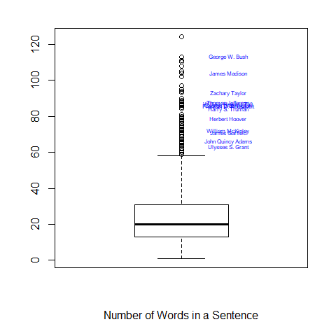

```r
bxpdat.sentence <- boxplot(sentence.list$word.count,
                           xlab="Number of Words in a Sentence")
text(x=1.2, y=bxpdat.sentence$out,
     labels=inaug.list$President[which(sentence.list$word.count%in%bxpdat.sentence$out)],
     cex=0.5, col="blue")
```

```r
# Summary of the length of sentences
print("Below is a summary of the length of sentences")
```

```
[1] "Below is a summary of the length of sentences"
```

```r
summary(sentence.list$word.count)
```

```
   Min. 1st Qu.  Median    Mean 3rd Qu.    Max.
   1.00   13.00   20.00   23.92   31.00  124.00
```

#### Word Cloud

**Wordcloud for all speeches**  
The words which appeared more often in speeches are larger in size and darker in color as shown in the words cloud. With no surprise , the most frequent words in all speeches include “will”, “government”, and “people”.

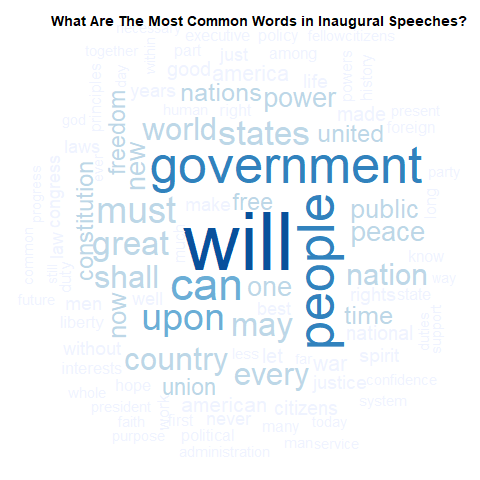

```r
set.seed(123)
wordcloud(tdm.overall$term, tdm.overall$`sum(count)`,
          scale=c(5,0.5),
          max.words=100,
          min.freq=1,
          random.order=FALSE,
          rot.per=0.3,
          use.r.layout=T,
          random.color=FALSE,
          colors=brewer.pal(5,"Blues")
          )
title(main="What Are The Most Common Words in Inaugural Speeches?", cex.main=0.9)
```

**Interactive Wordcloud for individual speeches**  
This coould be used to find the wordcloud of each individual speech as well as to compare between two different speeches.

```r
library(shiny)

shinyApp(
    ui = fluidPage(
      fluidRow(style = "padding-bottom: 20px;",
        column(4, selectInput('speech1', 'Speech 1',
                              speeches, selected=speeches[5])),
        column(4, selectInput('speech2', 'Speech 2',
                              speeches, selected=speeches[9])),
        column(4, sliderInput('nwords', 'Number of words', 3,
                              min = 20, max = 200, value=100, step = 20))
      ),
      fluidRow(
        plotOutput('wordclouds', height = "400px")
      )
    ),

    server = function(input, output, session) {
      # Combine the selected variables into a new data frame
      selectedData <- reactive({
        list(dtm.term1=dtm.tidy$term[dtm.tidy$document==
                                     as.character(which(speeches == input$speech1))],
             dtm.count1=dtm.tidy$count[dtm.tidy$document==
                                       as.character(which(speeches == input$speech1))],
             dtm.term2=dtm.tidy$term[dtm.tidy$document==
                                     as.character(which(speeches == input$speech2))],
             dtm.count2=dtm.tidy$count[dtm.tidy$document==
                                       as.character(which(speeches == input$speech2))])
      })

      output$wordclouds <- renderPlot(height = 400, {
        par(mfrow=c(1,2), mar = c(0, 0, 3, 0))
        wordcloud(selectedData()$dtm.term1,
                  selectedData()$dtm.count1,
              scale=c(4,0.5),
              max.words=input$nwords,
              min.freq=1,
              random.order=FALSE,
              rot.per=0.3,
              use.r.layout=T,
              random.color=FALSE,
              colors=brewer.pal(5,"Blues"),
            main=input$speech1)
        wordcloud(selectedData()$dtm.term2,
                  selectedData()$dtm.count2,
              scale=c(4,0.5),
              max.words=input$nwords,
              min.freq=1,
              random.order=FALSE,
              rot.per=0.3,
              use.r.layout=T,
              random.color=FALSE,
              colors=brewer.pal(5,"Blues"),
            main=input$speech2)
      })
    },

    options = list(height = 600)
)
```

#### Sentimental Analysis

```r
par(mar=c(2,2,2,1), mfrow=c(7,1))
Sentence.Length.Sentimetal.Plot(sentence.list,"WilliamJClinton",1)
Sentence.Length.Sentimetal.Plot(sentence.list,"WilliamJClinton",2)
Sentence.Length.Sentimetal.Plot(sentence.list,"GeorgeWBush",1)
Sentence.Length.Sentimetal.Plot(sentence.list,"GeorgeWBush",2)
Sentence.Length.Sentimetal.Plot(sentence.list,"BarackObama",1)
Sentence.Length.Sentimetal.Plot(sentence.list,"BarackObama",2)
Sentence.Length.Sentimetal.Plot(sentence.list,"DonaldJTrump",1)
```

Also, there are five inaugural addresses considered the best across all time. It includes Thomas Jefferson’s 1st(1801), Abraham Lincoln’s 2nd(1865), Franklin Roosevelt’s 1st(1933), Franklin Roosevelt’s 2nd(1937), John F. Kennedy’s(1961). Let’s take a closer look at them and see if you can find any similaries and differences among these five speeches, which may contribute to the great success of them.

```r
par(mar=c(2,2,2,1), mfrow=c(7,1))
Sentence.Length.Sentimetal.Plot(sentence.list,"ThomasJefferson",1)
Sentence.Length.Sentimetal.Plot(sentence.list,"AbrahamLincoln",2)
Sentence.Length.Sentimetal.Plot(sentence.list,"FranklinDRoosevelt",1)
Sentence.Length.Sentimetal.Plot(sentence.list,"FranklinDRoosevelt",2)
Sentence.Length.Sentimetal.Plot(sentence.list,"JohnFKennedy",1)
```

#### Topic Modeling

```r
# Run LDA (Latent Dirichlet allocation)

# Set parameters for Gibbs sampling
burnin <- 4000 # Drop the first 4000 samples
iter <- 2000
thin <- 500 # Pick only every 500 guesses
seed <-list(2003,5,63,100001,765)
nstart <- 5
best <- TRUE # Sample with the largest posterior distribution
k <- 8 # Number of topics

# Run LDA using Gibbs sampling
ldaOut.all <-LDA(dtm.all.lda, k, method="Gibbs", control=list(nstart=nstart,
                                                 seed = seed, best=best,
                                                 burnin = burnin, iter = iter,
                                                 thin=thin))
# Write out results
# Docs to topics
ldaOut.topics.all <- as.matrix(topics(ldaOut.all))
table(c(1:k, ldaOut.topics.all))
write.csv(ldaOut.topics.all,file=paste("../output/LDAGibbs ",
                                   k," DocsToTopics.csv", sep = ''))

# Top 10 terms in each topic
ldaOut.terms.all <- as.matrix(terms(ldaOut.all,10))
write.csv(ldaOut.terms.all,file=paste("../output/LDAGibbs ",
                                  k," TopicsToTerms.csv", sep = ''))

# Probabilities associated with each topic assignment
topicProbabilities.all <- as.data.frame(ldaOut.all@gamma)
write.csv(topicProbabilities.all,file=paste("../output/LDAGibbs ",
                                        k," TopicProbabilities.csv", sep = ''))

terms.beta <- ldaOut.all@beta
terms.beta <- scale(terms.beta)
topics.terms <- NULL
for(i in 1:k){
  topics.terms.all <- rbind(topics.terms,
                        ldaOut.all@terms[order(terms.beta[i,],
                                           decreasing = TRUE)[1:10]])
}
#topics.terms.all
ldaOut.terms.all[1:3,]
```

Based on the most popular terms and the most salient terms for each topic, we assign a hashtag to each topic.

```r
topics.hash <- c("Goverment", "War", "World", "Law",
                 "Time", "Nation", "People", "Country")
print(topics.hash)
corpus.list$ldatopic <- as.vector(ldaOut.topics.all)
corpus.list$ldahash <- topics.hash[ldaOut.topics.all]

colnames(topicProbabilities.all) <- topics.hash
corpus.list.df <- cbind(corpus.list, topicProbabilities.all)
```

```r
set.seed(123)
wordcloud(corpus.list.df$ldahash,
          scale=c(5,0.5),
          max.words=100,
          min.freq=1,
          random.order=FALSE,
          rot.per=0.3,
          use.r.layout=T,
          random.color=FALSE,
          colors=brewer.pal(5,"Blues")
          )
```

### Number of Terms Served

#### Overview

**Summary of Group of Interest**

| Number of Terms Served | Number of Presidents |
| --- | --- |
| One Term | 22 |
| Two Terms | 16 |
| Four Terms | 1 |

This analysis has primarily focused on presidents who served one or two terms. The analysis of the speeches of Franklin Roosevelt, who was the only POTUS who served more than two terms, may be incorporated in the furture.

#### Staging

```r
### Number of Terms Served
# Summary of groups by the number of terms served
inaug.list%>%
  group_by(Term)%>%
  summarise(Count = n_distinct(President))

# Identify 'File' for each group
twoplus.terms <- inaug.list$File[inaug.list$Term==2]
four.terms <- unique(inaug.list$File[inaug.list$Term>2])
two.terms <- twoplus.terms[twoplus.terms != four.terms]
one.term <- inaug.list$File[!(inaug.list$File%in%twoplus.terms)]

# Create group and group name
TermGroup <- list("One Term"=one.term, "Two Terms"=two.terms, "Four Terms"=four.terms)
TermGroup.name <- "Number of Terms Served"
```

POTUS are assigned into 3 groups by the number of terms they served.

- 22 POTUS who have served only one term:

```r
TermGroup$`One Term`
```

- 16 POTUS who have served two terms:

```r
TermGroup$`Two Terms`
```

- One POTUS who has served more than two terms:

```r
TermGroup$`Four Terms`
```

#### Length of Speeches

```r
par(mar=c(4.5,3,2,3), mfrow=c(1,2))

# Create bar plot of each speech
Speech.Length.Bar.Plot(inaug.list,TermGroup,TermGroup.name)
# Create box plot of each speech by group
Speech.Length.Box.Plot(inaug.list,TermGroup,TermGroup.name)
```

For POTUS who served two terms, we would like to see if there is any differece between their first term and second term.

```r
par(mar=c(4.5,3,2,3), mfrow=c(1,2))

# Create bar plot and box plot for 'Two Terms' group
i.var <- inaug.list%>%
          filter(File%in%unlist(TermGroup[2]),
                 Term%in%c(1,2))
i.var$File <- factor(i.var$File)
i.var$FileOrdered <- reorder(i.var$File, i.var$Words, mean, order=T)

i.x <- barplot(i.var$Words, space = 1,
               col = brewer.pal(9,"Blues")[c(4,7)],
               cex.axis = 0.7,
               main = "Number of Words in a Speech"
              )
text(cex=0.5, x=i.x-0.25, y=-1.25,
       adj=1, srt = 60, xpd = TRUE,
       labels = paste(substr(i.var$Date,1,4),
                      i.var$President))
legend("topright", inset= 0.02, legend =c("First Term", "Second Term"),
         text.col = brewer.pal(9,"Blues")[c(4,7)],
         cex = 0.7, box.lty=2 )

  boxplot(i.var$Words~i.var$Term,
          col=alpha(brewer.pal(9,"Blues"),1)[c(4,7)],
          cex.axis = 0.7,
          main = "Number of Words in a Speech")
```

#### Length of Sentences

```r
par(mar=c(4.5,5.5,2,1), mfrow=c(1,2))

Bee.Swarm.Plot(sentence.list,TermGroup,TermGroup.name)
Bee.Swarm.Plot.Group(sentence.list,TermGroup,TermGroup.name)
```

```r
Sentence.Searcher.Group(sentence.list,TermGroup,c("1","2","3","4"),FALSE)
Sentence.Searcher.Group(sentence.list,TermGroup,c("1","2","3","4"),TRUE)
```

For POTUS who served two terms, we would like to see if there is any differece between the their first term and sencond term.

```r
par(mar=c(4.5,5.5,2,1), mfrow=c(1,2))
# Create bee swarm plot for 'Two Terms' group

ii.var <- sentence.list%>%
            filter(File%in%unlist(TermGroup[2]),
                   Term%in%c(1,2))
ii.var$File <- factor(ii.var$File)
ii.var$FileOrdered <- reorder(ii.var$File, ii.var$word.count, mean, order=T)

beeswarm(word.count~FileOrdered,
             data = ii.var%>%filter(Term==1),
             horizontal = TRUE,
             pch=16, col=alpha(brewer.pal(9, "Blues")[4], 1),
             cex=0.55, cex.axis=0.55, cex.lab=1,
             spacing=5/nlevels(ii.var$FileOrdered),
             las=2, ylab="", xlab="",
             main="Number of Words in a Sentence")
beeswarm(word.count~FileOrdered,
             data = ii.var%>%filter(Term==2),
             add=TRUE,
             horizontal = TRUE,
             pch=16, col=alpha(brewer.pal(9, "Blues")[7], 1),
             cex=0.55, cex.axis=0.55, cex.lab=1,
             spacing=5/nlevels(ii.var$FileOrdered))

legend("bottomright", inset= 0.02, legend =c("First Term", "Second Term"),
         text.col = brewer.pal(9,"Blues")[c(4,7)],
         cex = 0.7, box.lty=2 )

beeswarm(word.count~Term,
             data = ii.var,
             horizontal = TRUE,
             pch=16, col=alpha(brewer.pal(9,
                                          "Blues")[c(4,7)],
                               0.4),
             cex=0.55, cex.axis=0.55, cex.lab=1,
             spacing=5/nlevels(ii.var$FileOrdered),
             las=2, ylab="", xlab="",
             main="Number of Words in a Sentence")
  legend("bottomright", inset=0.02, legend =c("First Term", "Second Term") ,
         text.col = brewer.pal(9,"Blues")[c(4,7)],
         cex = 0.7, box.lty=2 )
  boxplot(ii.var$word.count~ii.var$Term, horizontal=TRUE,
          col="#0000ff22", axes=FALSE, add=TRUE)
```

```r
Sentence.Searcher.Group(sentence.list,TermGroup,c("1"),FALSE)[,2]
Sentence.Searcher.Group(sentence.list,TermGroup,c("2"),FALSE)[,2]

Sentence.Searcher.Group(sentence.list,TermGroup,c("1"),TRUE)[,2]
Sentence.Searcher.Group(sentence.list,TermGroup,c("2"),TRUE)[,2]
```

#### Word Cloud

```r
par(mar=c(4.5,5.5,2,1), mfrow=c(1,length(TermGroup)))
set.seed(123)
Word.Cloud.Group(inaug.list,TermGroup,TermGroup.name)
```

For POTUS who served two terms, we would like to see if there is any differece between the their first term and sencond term.

```r
par(mar=c(4.5,5.5,2,1), mfrow=c(1,2))
set.seed(123)
for (i in 1:2){
  iii.var <- inaug.list%>%
             filter(File%in%unlist(TermGroup[2]))

  iii.docs <- Corpus(VectorSource(iii.var$Fulltext))
  iii.docs <- tm_map(iii.docs, stripWhitespace) # Eliminate extra whitespace
  iii.docs <- tm_map(iii.docs, content_transformer(tolower)) # Convert to lower case
  iii.docs <- tm_map(iii.docs, removeWords, stopwords("english")) # Remove stopwords
  iii.docs <- tm_map(iii.docs, removeWords, character(0))
  iii.docs <- tm_map(iii.docs, removePunctuation) # Remove punctuations
  #iii.docs <- tm_map(iii.docs, removeNumbers) # Remove numbers
  #iii.docs <- tm_map(iii.docs, stemDocument) # Stem document

  iii.tdm <- TermDocumentMatrix(iii.docs)
  iii.tdm.tidy <- tidy(iii.tdm)
  iii.tdm.var <- summarise(group_by(iii.tdm.tidy, term), sum(count))


  wordcloud(iii.tdm.var$term, iii.tdm.var$`sum(count)`,
                scale=c(5,0.5),
                max.words=100,
                min.freq=1,
                random.order=FALSE,
                rot.per=0.3,
                use.r.layout=T,
                random.color=FALSE,
                colors=brewer.pal(5, "Blues")
          )
  title(main = c("First Term","Second Term")[i],
            cex.main=1.5,
            col.main=brewer.pal(5, "Blues")[5])
}
```

#### Sentimental Analysis

**Clustering of Emotions**

```r
par(mar=c(4.5,5.5,2,1), mfrow=c(length(TermGroup),1))
# Create barplot of average value of emotions for each group
Sentimental.Analysis.Plots(sentence.list,TermGroup,TermGroup.name)
```

```r
par(mar=c(4.5,5.5,2,1), mfrow=c(2,1))
# Creat Heatmap for correlations and
# Barplot for average value of emotions for groups in In.Group

#  heatmap.2(cor(sentence.list%>%
#                filter(File%in%unlist(TermGroup[2]))%>%
#                select(anger:trust)),
#          scale = "none",
#          col = bluered(100), margin=c(6, 6), key=F,
#          trace = "none", density.info = "none")

  i.emo.means.var <- colMeans(sentence.list%>%
                         filter(File%in%unlist(TermGroup[2]),Term==1)%>%
                         select(anger:trust)>0.01)
  ii.emo.means.var <- colMeans(sentence.list%>%
                         filter(File%in%unlist(TermGroup[2]),Term==2)%>%
                         select(anger:trust)>0.01)
  barplot(i.emo.means.var[order(i.emo.means.var)],
        las=2, col=brewer.pal(8,"Pastel2")[order(i.emo.means.var)],
        horiz=T, main="First Term", xlab = "Average Value of Emotions")
  barplot(ii.emo.means.var[order(ii.emo.means.var)],
        las=2, col=brewer.pal(8,"Pastel2")[order(ii.emo.means.var)],
        horiz=T, main="Second Term", xlab = "Average Value of Emotions")
```

```r
i.emo.var <- sentence.list%>%
                         filter(File%in%unlist(TermGroup[2]),Term==1)%>%
                         select(sentences, fear,sadness)
ii.emo.var <- sentence.list%>%
                         filter(File%in%unlist(TermGroup[2]),Term==2)%>%
                         select(sentences, fear,sadness)

i.fear <- head(i.emo.var%>%arrange(desc(fear))%>%select(sentences))
ii.fear <- head(ii.emo.var%>%arrange(desc(fear))%>%select(sentences))
i.sadness <- head(i.emo.var%>%arrange(desc(sadness))%>%select(sentences))
ii.dadness <- head(ii.emo.var%>%arrange(desc(sadness))%>%select(sentences))
i.emo.df <- cbind(i.fear,ii.fear,i.sadness,ii.dadness)
colnames(i.emo.df) <- c("First Term Fear","Second Term Fear",
                        "Fist Term Sadness", "Second Term Sadness")
i.emo.df
```

**What are the emotionally charged sentences?**

```r
# What are the emotionally charged sentences?
Sentimental.Sentence.Searcher(sentence.list,TermGroup,c("1","2","3","4"))

Sentimental.Sentence.Searcher(sentence.list,TermGroup[2],c("1"))
Sentimental.Sentence.Searcher(sentence.list,TermGroup[2],c("2"))
```

```r
par(mar=c(4.5,5.5,2,1), mfrow=c(2,1))
# One Term
## Perform k-means clustering
clustering.rst <- Sentimental.Sentence.KMeans(sentence.list,TermGroup[1],c("1","2","3","4"))
## Visualze clustering results
fviz_cluster(clustering.rst[[1]],
             stand=F, repel= TRUE,
             data = clustering.rst[[2]][,-1],
             xlab="", xaxt="n",
             show.clust.cent=FALSE)

# Two  Terms
## Perform k-means clustering
clustering.rst <- Sentimental.Sentence.KMeans(sentence.list,TermGroup[2],c("1","2","3","4"))

## Visualze clustering results
fviz_cluster(clustering.rst[[1]],
             stand=F, repel= TRUE,
             data = clustering.rst[[2]][,-1],
             xlab="", xaxt="n",
             show.clust.cent=FALSE)
```

For POTUS who served two terms, we would like to see if there is any differece between their first term and second term.

```r
par(mar=c(4.5,5.5,2,1), mfrow=c(2,1))
# One Term
## Perform k-means clustering
clustering.rst <- Sentimental.Sentence.KMeans(sentence.list,TermGroup[2],c("1"))
## Visualze clustering results
fviz_cluster(clustering.rst[[1]],
             stand=F, repel= TRUE,
             data = clustering.rst[[2]][,-1],
             xlab="", xaxt="n",
             show.clust.cent=FALSE)

# Two  Terms
## Perform k-means clustering
clustering.rst <- Sentimental.Sentence.KMeans(sentence.list,TermGroup[2],c("2"))

## Visualze clustering results
fviz_cluster(clustering.rst[[1]],
             stand=F, repel= TRUE,
             data = clustering.rst[[2]][,-1],
             xlab="", xaxt="n",
             show.clust.cent=FALSE)
```

#### Topic Modeling

### Political Party

#### Overview

| Political Party | Number of Presidents |
| --- | --- |
| Republican | 17 |
| Democratic | 14 |

#### Staging

```r
### Political Party
# Summary of groups by politial party
inaug.list%>%
  group_by(Party)%>%
  summarise(Count = n_distinct(President))

# Identify 'File' for each group
Democrats <- inaug.list$File[inaug.list$Party=="Democratic"]
Republicans <- inaug.list$File[inaug.list$Party=="Republican"]

# Create group and group name
PartyGroup <- list("Republicans"=Republicans, "Democrats"=Democrats)
PartyGroup.name <- "Political Party"
```

31 POTUS are assigned into 2 groups by the political party they served, i.e., Republican vs. Democratic. The rest of the POTUS will not be in scope of the analysis in terms of the political party they served.

- 17 POTUS who are Republicans:

```r
PartyGroup$Republicans
```

- 14 POTUS who are Democrats:

```r
PartyGroup$Democrats
```

#### Length of Speeches

```r
par(mar=c(4.5,3,2,3), mfrow=c(1,2))

# Create bar plot of each speech
Speech.Length.Bar.Plot(inaug.list,PartyGroup,PartyGroup.name)
# Create box plot of each speech by group
Speech.Length.Box.Plot(inaug.list,PartyGroup,PartyGroup.name)
```

#### Length of Sentences

```r
par(mar=c(4.5,5.5,2,1), mfrow=c(1,2))

Bee.Swarm.Plot(sentence.list,PartyGroup,PartyGroup.name)
Bee.Swarm.Plot.Group(sentence.list,PartyGroup,PartyGroup.name)
```

```r
Sentence.Searcher.Group(sentence.list,PartyGroup,c("1","2","3","4"),FALSE)
Sentence.Searcher.Group(sentence.list,PartyGroup,c("1","2","3","4"),TRUE)
```

#### Word Cloud

```r
par(mar=c(4.5,5.5,2,1), mfrow=c(1,length(PartyGroup)))
set.seed(123)

Word.Cloud.Group(inaug.list,PartyGroup,PartyGroup.name)
```

#### Sentimental Analysis

**Clustering of Emotions**

```r
par(mar=c(4.5,5.5,2,1), mfrow=c(length(PartyGroup),1))
# Create barplot of average value of emotions for each group
Sentimental.Analysis.Plots(sentence.list,PartyGroup,PartyGroup.name)
```

```r
i.emo.var <- sentence.list%>%
                         filter(File%in%unlist(PartyGroup[1]))%>%
                         select(sentences, fear)
ii.emo.var <- sentence.list%>%
                         filter(File%in%unlist(PartyGroup[2]))%>%
                         select(sentences, fear)

i.fear <- head(i.emo.var%>%arrange(desc(fear))%>%select(sentences))
ii.fear <- head(ii.emo.var%>%arrange(desc(fear))%>%select(sentences))

i.emo.df <- cbind(i.fear,ii.fear)
colnames(i.emo.df) <- c("Republicans Fear","Democrats Fear")
i.emo.df
```

**What are the emotionally charged sentences?**

```r
# What are the emotionally charged sentences?
Sentimental.Sentence.Searcher(sentence.list,PartyGroup,c("1","2","3","4"))
```

```r
par(mar=c(4.5,5.5,2,1), mfrow=c(2,1))
# Reputlican
## Perform k-means clustering
clustering.rst <- Sentimental.Sentence.KMeans(sentence.list,PartyGroup[1],c("1","2","3","4"))
## Visualze clustering results
fviz_cluster(clustering.rst[[1]],
             stand=F, repel= TRUE,
             data = clustering.rst[[2]][,-1],
             xlab="", xaxt="n",
             show.clust.cent=FALSE)

# Democratic
## Perform k-means clustering
clustering.rst <- Sentimental.Sentence.KMeans(sentence.list,PartyGroup[2],c("1","2","3","4"))

## Visualze clustering results
fviz_cluster(clustering.rst[[1]],
             stand=F, repel= TRUE,
             data = clustering.rst[[2]][,-1],
             xlab="", xaxt="n",
             show.clust.cent=FALSE)
```

### Educational Background

#### Overview

| Educational Background | Number of Presidents |
| --- | --- |
| No Colledge | 9 |
| Undergraduate | 21 |
| Advanced Degree | 7 |

#### Staging

Educational backgound of POTUS were obtained from the following websites:

- [List of POTUS by education](https://en.wikipedia.org/wiki/List_of_Presidents_of_the_United_States_by_education)
- [Educational and Career Backgrounds of POTUS](https://ijr.com/2015/07/366694-charts-show-educational-work-backgrounds-presidential-candidates/)

```r
### Educational Background
# Indentify educational background of each POTUS
NoColledge <- c("GeorgeWashington", "JamesMonroe", "AndrewJackson",
                "MartinvanBuren", "ZacharyTaylor", "AbrahamLincoln",
                "GroverCleveland", "WilliamMcKinley", "HarrySTruman")
Undergrad <- c("ThomasJefferson","JamesMadison", "JohnQuincyAdams",
               "JamesKPolk", "FranklinPierce", "JamesBuchanan",
               "UlyssesSGrant", "JamesGarfield", "BenjaminHarrison",
               "TheodoreRoosevelt", "WarrenGHarding", "CalvinCoolidge",
               "HerbertHoover", "FranklinDRoosevelt", "DwightDEisenhower",
               "JohnFKennedy", "LyndonBJohnson", "JimmyCarter",
               "RonaldReagan", "GeorgeBush", "DonaldJTrump")
MA.MS <- c("JohnAdams")
MBA <- c("GeorgeWBush")
Law <- c("RutherfordBHayes", "RichardNixon", "WilliamJClinton", "BarackObama")
Doctorate <- c("WoodrowWilson")

Advanced.Degree <- c(MA.MS, MBA, Law, Doctorate)

# Group POTUS into three categories and Create group and group name
EducationGroup <- list("No Colledge"=NoColledge,
                        "Undergraduate"=Undergrad,
                        "Advanced Degree"=Advanced.Degree)
EducationGroup.name <- "Educational Background"

summary(Education.Group)[,1]
```

POTUS are assigned into 3 groups based on their highest education level.

- 9 POTUS without a colledge degree include:

```r
EducationGroup$`No Colledge`
```

- 21 POTUS with only undergraduate degree include:

```r
EducationGroup$Undergraduate
```

- 7 POTUS with more advanced degree include:

```r
EducationGroup$`Advanced Degree`
```

#### Length of Speeches

```r
par(mar=c(4.5,3,2,3), mfrow=c(1,2))

# Create bar plot of each speech
Speech.Length.Bar.Plot(inaug.list,EducationGroup,EducationGroup.name)
# Create box plot of each speech by group
Speech.Length.Box.Plot(inaug.list,EducationGroup,EducationGroup.name)
```

#### Length of Sentences

```r
par(mar=c(4.5,5.5,2,1), mfrow=c(1,2))

Bee.Swarm.Plot(sentence.list,EducationGroup,EducationGroup.name)
Bee.Swarm.Plot.Group(sentence.list,EducationGroup,EducationGroup.name)
```

```r
Sentence.Searcher.Group(sentence.list,EducationGroup,c("1","2","3","4"),FALSE)
Sentence.Searcher.Group(sentence.list,EducationGroup,c("1","2","3","4"),TRUE)
```

#### Word Cloud

```r
par(mar=c(4.5,5.5,2,1), mfrow=c(1,length(EducationGroup)))
set.seed(123)

Word.Cloud.Group(inaug.list,EducationGroup,EducationGroup.name)
```

#### Sentimental Analysis

**Clustering of Emotions**

```r
par(mar=c(4.5,5.5,2,1), mfrow=c(length(EducationGroup),1))
# Create barplot of average value of emotions for each group
Sentimental.Analysis.Plots(sentence.list,EducationGroup,EducationGroup.name)
```

**What are the emotionally charged sentences?**

```r
# What are the emotionally charged sentences?
Sentimental.Sentence.Searcher(sentence.list,EducationGroup,c("1","2","3","4"))
```

```r
par(mar=c(4.5,5.5,2,1), mfrow=c(2,1))
# No Colledge Degree
## Perform k-means clustering
clustering.rst <- Sentimental.Sentence.KMeans(sentence.list,EducationGroup[1],c("1","2","3","4"))
## Visualze clustering results
fviz_cluster(clustering.rst[[1]],
             stand=F, repel= TRUE,
             data = clustering.rst[[2]][,-1],
             xlab="", xaxt="n",
             show.clust.cent=FALSE)

# Undergraduate Degree Only
## Perform k-means clustering
clustering.rst <- Sentimental.Sentence.KMeans(sentence.list,EducationGroup[2],c("1","2","3","4"))
## Visualze clustering results
fviz_cluster(clustering.rst[[1]],
             stand=F, repel= TRUE,
             data = clustering.rst[[2]][,-1],
             xlab="", xaxt="n",
             show.clust.cent=FALSE)

# Advenced Degree
## Perform k-means clustering
clustering.rst <- Sentimental.Sentence.KMeans(sentence.list,EducationGroup[3],c("1","2","3","4"))
## Visualze clustering results
fviz_cluster(clustering.rst[[1]],
             stand=F, repel= TRUE,
             data = clustering.rst[[2]][,-1],
             xlab="", xaxt="n",
             show.clust.cent=FALSE)
```

### Career Prior to Politics

#### Overview

| Career Prior to Politics | Number of Presidents |
| --- | --- |
| Lawyer | 21 |
| Military Leader | 3 |
| Farmer | 3 |
| Educator | 2 |
| Businessperson | 3 |

#### Staging

Career backgound of POTUS were obtained from the following website:

- [Educational and Career Backgrounds of POTUS](https://ijr.com/2015/07/366694-charts-show-educational-work-backgrounds-presidential-candidates/)

```r
### Career Prior to Politics
# Indentify career background of each POTUS
lawyer <- c("JohnAdams", "ThomasJefferson", "JamesMadison",
            "JamesMonroe", "JohnQuincyAdams", "AndrewJackson",
            "MartinvanBuren", "JamesKPolk", "FranklinPierce",
            "JamesBuchanan", "AbrahamLincoln", "RutherfordBHayes",
            "JamesGarfield", "GroverCleveland", "BenjaminHarrison",
            "WilliamMcKinley", "CalvinCoolidge", "FranklinDRoosevelt",
            "RichardNixon", "WilliamJClinton", "BarackObama")
military.leader <- c("ZacharyTaylor", "UlyssesSGrant", "DwightDEisenhower")
farmer <- c("GeorgeWashington", "HarrySTruman", "JimmyCarter")
businessperson <- c("GeorgeBush", "GeorgeWBush", "DonaldJTrump")
educator <- c("WoodrowWilson", "LyndonBJohnson")

# Group POTUS into five categories and Create group and group name
CareerGroup <- list("Lawyer"=lawyer,
               "Military Learder"=military.leader,
               "Farmer"=farmer,
               "Educator"=educator,
               "Businessperson"=businessperson)
CareerGroup.name <- "Career Prior to Politics"
summary(Career.Group)[,1]
```

POTUS are assigned into 5 groups based on their career pior to politics.

- 21 POTUS were lawywers include:

```r
CareerGroup$Lawyer
```

- 3 POTUS were military leaders:

```r
CareerGroup$`Military Learder`
```

- 3 POTUS were farmers:

```r
CareerGroup$Farmer
```

- 2 POTUS were educators:

```r
CareerGroup$Educator
```

- 3 POTUS were businesspersons:

```r
CareerGroup$Businessperson
```

#### Length of Speeches

```r
par(mar=c(4.5,3,2,3), mfrow=c(1,2))

# Create bar plot of each speech
Speech.Length.Bar.Plot(inaug.list,CareerGroup,CareerGroup.name)
# Create box plot of each speech by group
Speech.Length.Box.Plot(inaug.list,CareerGroup,CareerGroup.name)
```

#### Length of Sentences

```r
par(mar=c(4.5,5.5,2,1), mfrow=c(1,2))

Bee.Swarm.Plot(sentence.list,CareerGroup,CareerGroup.name)
Bee.Swarm.Plot.Group(sentence.list,CareerGroup,CareerGroup.name)
```

```r
Sentence.Searcher.Group(sentence.list,CareerGroup,c("1","2","3","4"),FALSE)
Sentence.Searcher.Group(sentence.list,CareerGroup,c("1","2","3","4"),TRUE)
```

#### Word Cloud

```r
par(mar=c(4.5,5.5,2,1), mfrow=c(1,length(CareerGroup)))
set.seed(123)

Word.Cloud.Group(inaug.list,CareerGroup,CareerGroup.name)
```

#### Sentimental Analysis

**Clustering of Emotions**

```r
par(mar=c(4.5,5.5,2,1), mfrow=c(length(CareerGroup),1))
# Create barplot of average value of emotions for each group
Sentimental.Analysis.Plots(sentence.list,CareerGroup,CareerGroup.name)
```

**What are the emotionally charged sentences?**

```r
# What are the emotionally charged sentences?
Sentimental.Sentence.Searcher(sentence.list,CareerGroup,c("1","2","3","4"))
```

We would like to take a look at the cluster plot of the Lawyer group, as size of other groups are quite small.

```r
par(mar=c(4.5,5.5,2,1), mfrow=c(2,1))
# Lawyer
## Perform k-means clustering
clustering.rst <- Sentimental.Sentence.KMeans(sentence.list,CareerGroup[1],c("1","2","3","4"))
## Visualze clustering results
fviz_cluster(clustering.rst[[1]],
             stand=F, repel= TRUE,
             data = clustering.rst[[2]][,-1],
             xlab="", xaxt="n",
             show.clust.cent=FALSE)
```

### Served During War Era?

#### Overview

[output not shown]

#### Staging

The following website was used as a reference to understand more about the U.S. history. It presents a timeline of the U.S. hitory, which specifies the wars the U.S. was involded in.

- [Animated Atlas](http://www.animatedatlas.com/timeline.html)

POTUS are assigned into two groups based on whether it was war era while they were serving.

```r
### Served During War Era?
# Indentify POTUS who served during war eras
war.era <- c("JamesMadison", "JamesKPolk", "AbrahamLincoln",
             "WilliamMcKinley", "WoodrowWilson", "FranklinDRoosevelt",
             "HarrySTruman", "LyndonBJohnson", "RichardNixon",
             "GeorgeBush", "GeorgeWBush")
nowar.era <- inaug.list$File[!(inaug.list$File%in%war.era)]

# Create group and group name
WarGroup <- list("No War Era"=nowar.era, "War Era"=war.era)
WarGroup.name <- "Whether Served During War Era"

summary(WarGroup)[,1]
```

#### Length of Speeches

```r
par(mar=c(4.5,3,2,3), mfrow=c(1,2))

# Create bar plot of each speech
Speech.Length.Bar.Plot(inaug.list,WarGroup,WarGroup.name)
# Create box plot of each speech by group
Speech.Length.Box.Plot(inaug.list,WarGroup,WarGroup.name)
```

#### Length of Sentences

```r
par(mar=c(4.5,5.5,2,1), mfrow=c(1,2))

Bee.Swarm.Plot(sentence.list,WarGroup,WarGroup.name)
Bee.Swarm.Plot.Group(sentence.list,WarGroup,WarGroup.name)
```

```r
Sentence.Searcher.Group(sentence.list,WarGroup,c("1","2","3","4"),FALSE)
Sentence.Searcher.Group(sentence.list,WarGroup,c("1","2","3","4"),TRUE)
```

#### Word Cloud

```r
par(mar=c(4.5,5.5,2,1), mfrow=c(1,length(WarGroup)))
set.seed(123)

Word.Cloud.Group(inaug.list,WarGroup,WarGroup.name)
```

#### Sentimental Analysis

**Clustering of Emotions**

```r
par(mar=c(4.5,5.5,2,1), mfrow=c(length(WarGroup),1))
# Create barplot of average value of emotions for each group
Sentimental.Analysis.Plots(sentence.list,WarGroup,WarGroup.name)
```

**What are the emotionally charged sentences?**

```r
# What are the emotionally charged sentences?
Sentimental.Sentence.Searcher(sentence.list,WarGroup,c("1","2","3","4"))
```

```r
par(mar=c(4.5,5.5,2,1), mfrow=c(2,1))
# No War Era
## Perform k-means clustering
clustering.rst <- Sentimental.Sentence.KMeans(sentence.list,WarGroup[1],c("1","2","3","4"))
## Visualze clustering results
fviz_cluster(clustering.rst[[1]],
             stand=F, repel= TRUE,
             data = clustering.rst[[2]][,-1],
             xlab="", xaxt="n",
             show.clust.cent=FALSE)
# War Era
## Perform k-means clustering
clustering.rst <- Sentimental.Sentence.KMeans(sentence.list,WarGroup[2],c("1","2","3","4"))
## Visualze clustering results
fviz_cluster(clustering.rst[[1]],
             stand=F, repel= TRUE,
             data = clustering.rst[[2]][,-1],
             xlab="", xaxt="n",
             show.clust.cent=FALSE)
```

## References

- [The American Presidentcy Project](http://www.presidency.ucsb.edu/inaugurals.php)
- [List of POTUS](https://en.wikipedia.org/wiki/List_of_Presidents_of_the_United_States)
- [List of POTUS by education](https://en.wikipedia.org/wiki/List_of_Presidents_of_the_United_States_by_education)
- [Educational and Career Backgrounds of POTUS](https://ijr.com/2015/07/366694-charts-show-educational-work-backgrounds-presidential-candidates/)
- [Animated Atlas](http://www.animatedatlas.com/timeline.html)
- [ADS Github](https://github.com/TZstatsADS/ADS_Teaching/tree/master/Tutorials/wk2-TextMining)